# Project MOBIL

First, we load all necessary packages

```r
library(readr)
library(data.table)
library(summarytools)
library(hdm)
library(glmnet)
```

```r
library(DoubleML)
library(mlr3)
library(ranger)
library(ggplot2)
library(ggpubr)
```

# 1. Data cleaning process

We import GDIM 2023 database for the official website

```r
url = "https://datacatalogfiles.worldbank.org/ddh-published/0050771/DR0065670/GDIM_2023_03.csv"
data_raw = read.csv(url)
head(data_raw)
```

|  | country | code | region | region_noHICgroup | incgroup2 | incgroup3 | incgroup4 | fragile | survey | year | status | cohort | parent | child | obs | P1 | P2 | P3 | P4 | P5 | C1 | C2 | C3 | C4 | C5 | MEANp | MEANc | SDp | SDc | … |
| --- | --- | --- | --- | --- | --- | --- | --- | --- | --- | --- | --- | --- | --- | --- | --- | --- | --- | --- | --- | --- | --- | --- | --- | --- | --- | --- | --- | --- | --- | --- |
| 1 | Afghanistan | AFG | South Asia | South Asia | Developing economies | Low income | Low income | Yes | NRVA | 2011 | Co-residents only | 1980 | avg | all | 3956 | 0.6661248 | 0.09858292 | 0.17093068 | 0.04303147 | 0.02133018 | 0.5118570 | 0.02580462 | 0.1641913 | 0.1834691 | 0.1146780 | 2.480162 | 5.582401 | 3.809782 | 5.857765 | … |
| 2 | Afghanistan | AFG | South Asia | South Asia | Developing economies | Low income | Low income | Yes | NRVA | 2011 | Co-residents only | 1980 | avg | daughter | 721 | 0.6153211 | 0.09927175 | 0.21277559 | 0.05196906 | 0.02066248 | 0.6284814 | 0.02337842 | 0.0992651 | 0.1323224 | 0.1165526 | 2.989992 | 4.331731 | 4.010379 | 5.902685 | … |
| 3 | Afghanistan | AFG | South Asia | South Asia | Developing economies | Low income | Low income | Yes | NRVA | 2011 | Co-residents only | 1980 | avg | son | 3235 | 0.6786987 | 0.09841243 | 0.16057406 | 0.04081942 | 0.02149544 | 0.4829925 | 0.02640510 | 0.1802605 | 0.1961279 | 0.1142140 | 2.353979 | 5.891941 | 3.748495 | 5.806141 | … |
| 4 | Afghanistan | AFG | South Asia | South Asia | Developing economies | Low income | Low income | Yes | NRVA | 2011 | Co-residents only | 1980 | dad | all | 4137 | 0.6865805 | 0.04760981 | 0.05730859 | 0.15090708 | 0.05759400 | 0.5145621 | 0.02604694 | 0.1656379 | 0.1815510 | 0.1122020 | 3.756049 | 5.538275 | 5.493762 | 5.842035 | … |
| 5 | Afghanistan | AFG | South Asia | South Asia | Developing economies | Low income | Low income | Yes | NRVA | 2011 | Co-residents only | 1980 | dad | daughter | 744 | 0.6390916 | 0.05232841 | 0.05408631 | 0.19009995 | 0.06439372 | 0.6303540 | 0.02278138 | 0.1037357 | 0.1295529 | 0.1135761 | 4.520877 | 4.277768 | 5.804775 | 5.869737 | … |
| 6 | Afghanistan | AFG | South Asia | South Asia | Developing economies | Low income | Low income | Yes | NRVA | 2011 | Co-residents only | 1980 | dad | son | 3393 | 0.6981243 | 0.04646278 | 0.05809188 | 0.14137988 | 0.05594109 | 0.4864149 | 0.02684075 | 0.1806854 | 0.1941910 | 0.1118680 | 3.570130 | 5.844686 | 5.400092 | 5.794936 | … |

[output not shown]

We create our research data from the GDIM data

```r
data_raw = data_raw[,c(1,4,5,8,12:14,26:29,31,40)] #removing unnecessary var
df = data.frame(
  mobility = data_raw$CAT,
  inequality = data_raw$SDc - data_raw$SDp,
  expansion = data_raw$MEANc - data_raw$MEANp,
  dependency = data_raw$COR, # parental dependency
  cohort = as.factor(data_raw$cohort), # generations
  fragile = as.factor(data_raw$fragile),
  developing = as.factor(ifelse(data_raw$incgroup2 == "Developing economies", "Yes", "No")),
  region = as.factor(data_raw$region_noHICgroup),
  mom = as.factor(ifelse(data_raw$parent == "mom", "Yes", "No")),
  daughter = as.factor(ifelse(data_raw$child == "daughter", "Yes", "No"))
)
```

We summarize our data set as follow:

```r
dfSummary(df,
               plain.ascii  = FALSE,
               style        = "grid",
               graph.magnif = 0.75,
               graph.col = FALSE,
               valid.col    = FALSE)
```

|  | No | Variable | Stats / Values | Freqs (% of Valid) | Missing |
| --- | --- | --- | --- | --- | --- |
| 1 | 1 | mobility\\\n[numeric] | Mean (sd) : 0.5 (0.2)\\\nmin < med < max:\\\n0 < 0.6 < 1\\\nIQR (CV) : 0.3 (0.4) | 6630 distinct values | 0\\\n(0.0%) |
| 2 | 2 | inequality\\\n[numeric] | Mean (sd) : 0.2 (1.3)\\\nmin < med < max:\\\n-3.2 < 0 < 5.2\\\nIQR (CV) : 1.7 (6.5) | 6681 distinct values | 0\\\n(0.0%) |
| 3 | 3 | expansion\\\n[numeric] | Mean (sd) : 3.1 (1.9)\\\nmin < med < max:\\\n-3.4 < 3.1 < 10.9\\\nIQR (CV) : 2.6 (0.6) | 6678 distinct values | 0\\\n(0.0%) |
| 4 | 4 | dependency\\\n[numeric] | Mean (sd) : 0.4 (0.1)\\\nmin < med < max:\\\n-0.1 < 0.4 < 1\\\nIQR (CV) : 0.2 (0.3) | 6674 distinct values | 0\\\n(0.0%) |
| 5 | 5 | cohort\\\n[factor] | 1\\. 1940\\\n2\\. 1950\\\n3\\. 1960\\\n4\\. 1970\\\n5\\. 1980 | \\1189 (17.7%)\\\n\\1259 (18.7%)\\\n\\1275 (19.0%)\\\n\\1271 (18.9%)\\\n\\1731 (25.7%) | 0\\\n(0.0%) |
| 6 | 6 | fragile\\\n[factor] | 1\\. No\\\n2\\. Yes | \\5890 (87.6%)\\\n\\ 835 (12.4%) | 0\\\n(0.0%) |
| 7 | 7 | developing\\\n[factor] | 1\\. No\\\n2\\. Yes | \\2227 (33.1%)\\\n\\4498 (66.9%) | 0\\\n(0.0%) |
| 8 | 8 | region\\\n[factor] | 1\\. East Asia & Pacific\\\n2\\. Europe & Central Asia\\\n3\\. Latin America & Caribbean\\\n4\\. Middle East & North Afric\\\n5\\. North America\\\n6\\. South Asia\\\n7\\. Sub-Saharan Africa | \\ 837 (12.4%)\\\n\\2788 (41.5%)\\\n\\ 687 (10.2%)\\\n\\ 468 ( 7.0%)\\\n\\ 120 ( 1.8%)\\\n\\ 332 ( 4.9%)\\\n\\1493 (22.2%) | 0\\\n(0.0%) |
| 9 | 9 | mom\\\n[factor] | 1\\. No\\\n2\\. Yes | \\5091 (75.7%)\\\n\\1634 (24.3%) | 0\\\n(0.0%) |
| 10 | 10 | daughter\\\n[factor] | 1\\. No\\\n2\\. Yes | \\4483 (66.7%)\\\n\\2242 (33.3%) | 0\\\n(0.0%) |

[output not shown]

# 2. Descriptive analysis

## 2.1. Scatter plots with continuous variables

First, we create a function to apply all continuous variables:

```r
plot_scatter <- function(x_var, y_var) {
  ggscatter(df, x_var, y_var,
            color = "grey",
            add = "reg.line",
            add.params = list(color = "blue", fill = "lightgray"),
            conf.int = TRUE) +
    stat_cor(method = "pearson",label.y = 1.1) + ylim(0, 1.1)
}
```

The Figure 2 in the study was generated by this code:

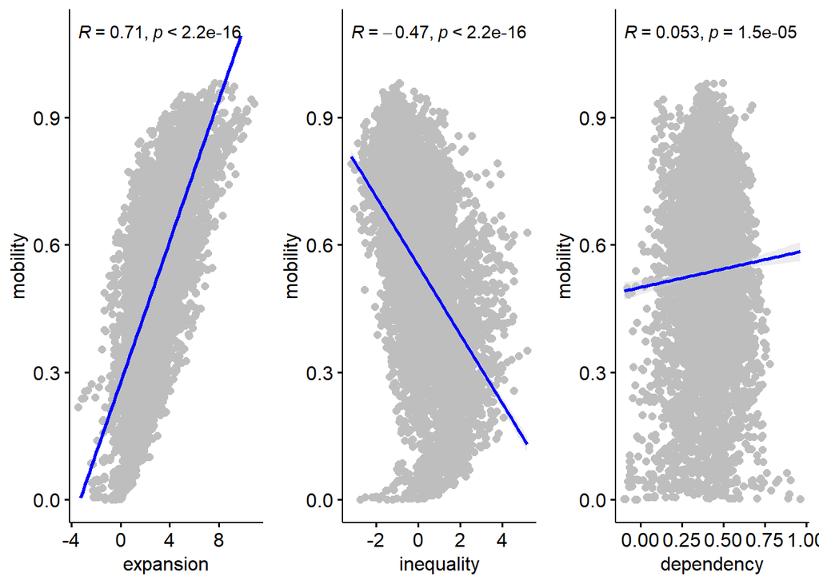

```r
Fig_2 = ggarrange(plot_scatter("expansion", "mobility"),
          plot_scatter("inequality", "mobility"),
          plot_scatter("dependency", "mobility"),
          ncol = 3, nrow = 1)
print(Fig_2)
```

Here, we pull out data of some countries (corresponding to each region) to demonstrate the change in intergenerational mobility across time and country in terms of gender effects.

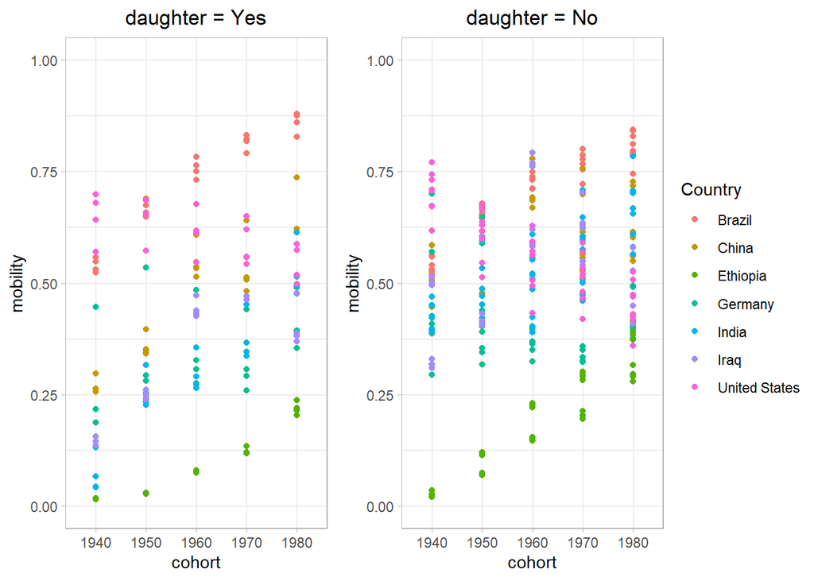

```r
df1 <- df
df1$Country <- data_raw$country
df1 <- df1[df1$Country %in% c("China", "Germany", "Brazil", "Iraq", "United States", "India", "Ethiopia"), ]

library(ggpubr)

Fig_2a <- ggplot(df1[df1$daughter == 'Yes', ], aes(x=cohort, y=mobility, color=Country)) +
  ggtitle('daughter = Yes') +
  geom_point() +
  theme_light() +
  scale_y_continuous(limits = c(0, 1)) +
  theme(legend.position = "none")  +
  theme(plot.title = element_text(hjust = 0.5))

Fig_2b <- ggplot(df1[df1$daughter == 'No', ], aes(x=cohort, y=mobility, color=Country)) +
  ggtitle('daughter = No') +
  geom_point() +
  theme_light() +
  scale_y_continuous(limits = c(0, 1)) +
  theme(legend.position = "none") +
  theme(plot.title = element_text(hjust = 0.5))

Fig_2_extra <- ggarrange(Fig_2a, Fig_2b, ncol = 2, nrow = 1, common.legend = TRUE, legend="right")
print(Fig_2_extra)
```

## 2.2. Violin plots with categorical variables

First, we create a function to apply all categorical variables:

```r
plot_violin <- function(x_var, y_var) {
  ggviolin(df, x = x_var, y = y_var, fill = x_var,
           legend.position = "none",
           add = "boxplot", add.params = list(fill = "white")) +
    stat_compare_means(method = "anova", label.y = 1.1) + guides(fill = FALSE)
}
```

The Figure 4 in the study was generated by this code:

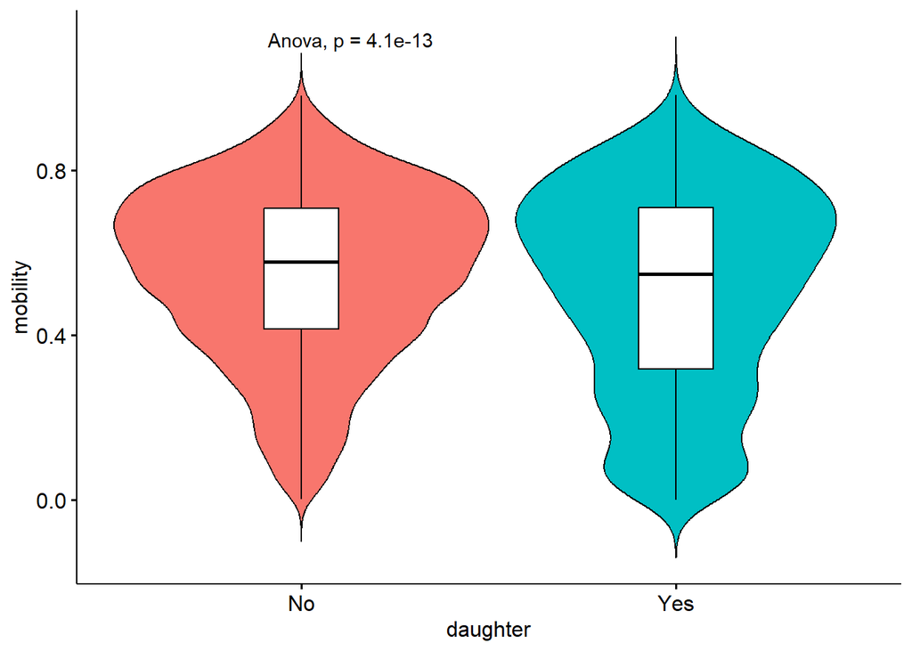

```r
Fig_4 = plot_violin("daughter", "mobility")
print(Fig_4)
```

The Figure 1 in the study was generated by this code:

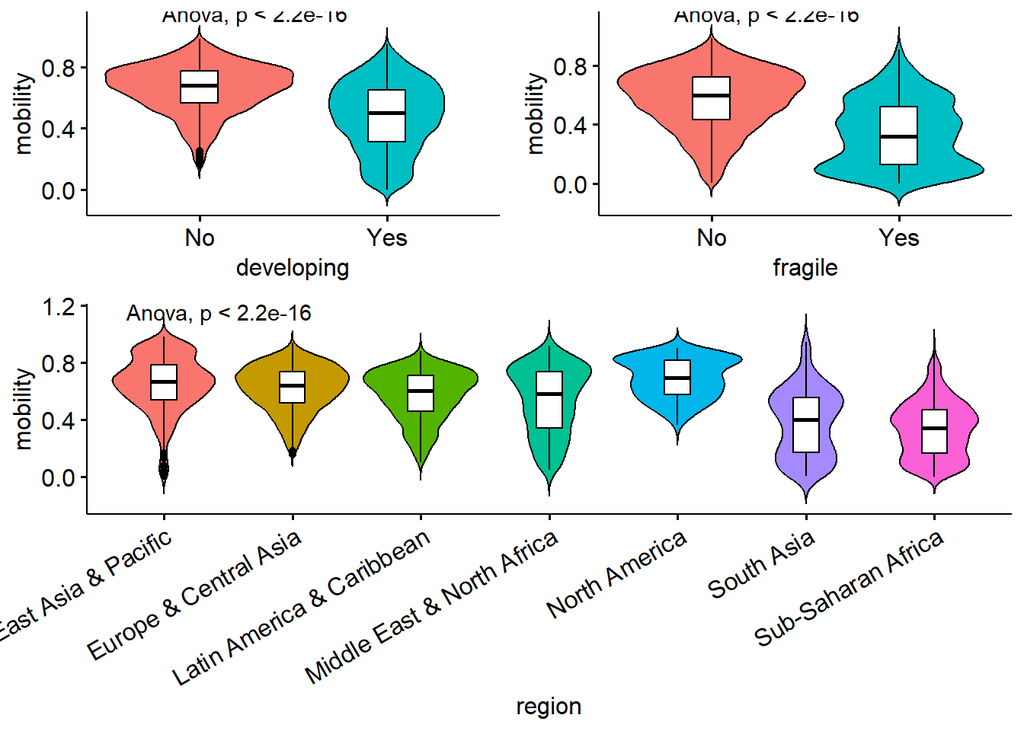

```r
Fig_1 = ggarrange(ggarrange(plot_violin("developing", "mobility"),
                    plot_violin("fragile", "mobility"),
                    ncol = 2, nrow = 1),
          plot_violin("region", "mobility") + rotate_x_text(30),
          ncol = 1, nrow = 2, heights=c(1,1.5))
print(Fig_1)
```

# 3. Data modelling

First, we convert the current research to fit well a research model:

```r
data <- df
data$mobility <- with(data_raw, CAT - ave(CAT, country)) # remove fixed effects
offset <- abs(min(data[sapply(data, is.numeric)])) + 1
data[sapply(data, is.numeric)] <- log(data[sapply(data, is.numeric)] + offset)
data <- model.matrix(~ . - 1, data = data) # convert into model data
data <- data[, -which(colnames(data) == "cohort1940")] # transform to dummy-coding
colnames(data) <- gsub("[^[:alnum:]]", "", colnames(data)) # correct var names
```

Then, we summarize the modeled data as follow:

```r
dfSummary(data,
               plain.ascii  = FALSE,
               style        = "grid",
               graph.magnif = 0.75,
               graph.col = FALSE,
               valid.col    = FALSE)
```

```
## data was converted to a data frame
```

|  | No | Variable | Stats / Values | Freqs (% of Valid) | Missing |
| --- | --- | --- | --- | --- | --- |
| 1 | 1 | mobility\\\n[numeric] | Mean (sd) : 1.5 (0)\\\nmin < med < max:\\\n1.4 < 1.5 < 1.6\\\nIQR (CV) : 0 (0) | 6633 distinct values | 0\\\n(0.0%) |
| 2 | 2 | inequality\\\n[numeric] | Mean (sd) : 1.5 (0.3)\\\nmin < med < max:\\\n0.2 < 1.5 < 2.3\\\nIQR (CV) : 0.4 (0.2) | 6681 distinct values | 0\\\n(0.0%) |
| 3 | 3 | expansion\\\n[numeric] | Mean (sd) : 2 (0.3)\\\nmin < med < max:\\\n0 < 2 < 2.7\\\nIQR (CV) : 0.3 (0.1) | 6678 distinct values | 0\\\n(0.0%) |
| 4 | 4 | dependency\\\n[numeric] | Mean (sd) : 1.6 (0)\\\nmin < med < max:\\\n1.5 < 1.6 < 1.7\\\nIQR (CV) : 0 (0) | 6674 distinct values | 0\\\n(0.0%) |
| 5 | 5 | cohort1950\\\n[numeric] | Min : 0\\\nMean : 0.2\\\nMax : 1 | 0 : 5466 (81.3%)\\\n1 : 1259 (18.7%) | 0\\\n(0.0%) |
| 6 | 6 | cohort1960\\\n[numeric] | Min : 0\\\nMean : 0.2\\\nMax : 1 | 0 : 5450 (81.0%)\\\n1 : 1275 (19.0%) | 0\\\n(0.0%) |
| 7 | 7 | cohort1970\\\n[numeric] | Min : 0\\\nMean : 0.2\\\nMax : 1 | 0 : 5454 (81.1%)\\\n1 : 1271 (18.9%) | 0\\\n(0.0%) |
| 8 | 8 | cohort1980\\\n[numeric] | Min : 0\\\nMean : 0.3\\\nMax : 1 | 0 : 4994 (74.3%)\\\n1 : 1731 (25.7%) | 0\\\n(0.0%) |
| 9 | 9 | fragileYes\\\n[numeric] | Min : 0\\\nMean : 0.1\\\nMax : 1 | 0 : 5890 (87.6%)\\\n1 : 835 (12.4%) | 0\\\n(0.0%) |
| 10 | 10 | developingYes\\\n[numeric] | Min : 0\\\nMean : 0.7\\\nMax : 1 | 0 : 2227 (33.1%)\\\n1 : 4498 (66.9%) | 0\\\n(0.0%) |

[output cut: 8 more lines]

[output not shown]

## 3.1. For the research question Q1

In this section, we attempt to estimate **the direct and indirect effects** of the target variables (education inequality, education expansion, and parental dependence).

### 3.1.1. Rigorous Lasso without interaction

This model addresses multicollinearity among explanatory variables, so produce a **pure** effects. In this study, it measures **the direct effects** of the target variables. First, we create a function for this kind of model:

```r
partiall_out <- function(dt,y, dvar) {
  x <- as.matrix(data)[,-c(which(colnames(dt) == y), which(colnames(dt) == dvar))]
  y <- data[, y]
  d <- data[, dvar]
  effect <- rlassoEffect(x, y, d)
  result <- summary(effect)
  result_df <- as.data.frame(result$coefficients)
  rownames(result_df)[rownames(result_df) == "d1"] = dvar
  return(result_df)
}
```

Then, we run this model to answer the question Q1:

```r
Q1_dl = rbind(partiall_out(data,"mobility","inequality"),
              partiall_out(data,"mobility","expansion"),
              partiall_out(data,"mobility","dependency")
)
print(Q1_dl)
```

```
##              Estimate.  Std. Error   t value     Pr(>|t|)
## inequality -0.01140383 0.001053242 -10.82736 2.554028e-27
## expansion   0.05999761 0.001447368  41.45290 0.000000e+00
## dependency -0.12597851 0.011041668 -11.40937 3.754243e-30
```

### 3.1.2. Double machine learning - PLR model

This model addresses confounding problems, therefore, it produces the **total impacts** (include direct and indirect effects).

First, we create a function for this kind of model:

```r
fit_dml_plr <- function(dt, y, d) {
  dt = as.data.table(dt)
  dml_data <- DoubleMLData$new(dt, y_col = y, d_cols = d,
                               x_cols = colnames(dt)[!(colnames(dt) %in% c(y,d))])
  set.seed(123) # required to replicate sample split
  learner_l <- lrn("regr.ranger", num.trees = 500, min.node.size = 2, max.depth = 5)
  learner_m <- lrn("regr.ranger", num.trees = 500, min.node.size = 2, max.depth = 5)
  dml_plr <- DoubleMLPLR$new(dml_data,
                             ml_l = learner_l,
                             ml_m = learner_m)
  dml_plr$fit()
  result <- dml_plr$summary()
  return(result)
}
```

Then, we run this model to answer the question Q1:

```r
Q1_plr = rbind(fit_dml_plr(data,"mobility","inequality"),
               fit_dml_plr(data,"mobility","expansion"),
               fit_dml_plr(data,"mobility","dependency"))
```

[output not shown]

```r
print(Q1_plr)
```

```
##               Estimate.  Std. Error   t value     Pr(>|t|)
## inequality -0.009251571 0.001170364 -7.904863 2.682284e-15
## expansion   0.054348805 0.001393057 39.014056 0.000000e+00
## dependency -0.099513038 0.011429301 -8.706835 3.124785e-18
```

## 3.2. For the research question Q2

In this section, we attempt to estimate the multidimensional effects of gender on the intergenerational mobility by the Rigorous Lasso with interaction (each interaction serves a dimension), and finally to confirm the overall effect of gender on the mobility by Double machine learning - IRM model.

### 3.2.1. Rigorous Lasso with interaction

This model addresses multicollinearity among variables, so it produces **the pure effects**. To account for the multidimensional effects, we add interaction terms in to this model.

First, we create a function for this kind of model:

```r
rlasso_effects <- function(dt, y, x) {
  dt = as.data.frame(dt)
  # Get all column names except x and y
  all_cols <- setdiff(names(dt), c(x, y))
  # Model matrix
  x_names <- paste(all_cols, collapse = "+")
  formula <- as.formula(paste0("~ -1 + ", x, "+", x, ":(", x_names, ")+(", x_names, ")^2"))
  X <- model.matrix(formula, data = dt)
  X <- X[, which(apply(X, 2, var) != 0)] #exclude constant variables
  index_x <- grep(x, colnames(X))
  effects <- rlassoEffects(x = X, y = dt[, y], index = index_x)
  result <- summary(effects)
  result_df <- as.data.frame(result$coefficients)
  return(result_df)
}
```

Then, we run this model to answer the question Q2:

```r
Q2_mom_dl = rlasso_effects(data,"mobility","momYes")
Q2_dau_dl = rlasso_effects(data,"mobility","daughterYes")
print(Q2_mom_dl)
```

```
##                                        Estimate.  Std. Error     t value
## momYes                             -0.0878147004 0.030320470 -2.89621835
## momYes:inequality                   0.0048277815 0.001984897  2.43225774
## momYes:expansion                    0.0057241192 0.002053814  2.78706769
## momYes:dependency                   0.0473280598 0.019496014  2.42757620
## momYes:cohort1950                   0.0001890374 0.001643214  0.11504120
## momYes:cohort1960                  -0.0007093963 0.001639589 -0.43266709
## momYes:cohort1970                  -0.0007660412 0.001638096 -0.46764123
## momYes:cohort1980                  -0.0006247323 0.001537323 -0.40637680
## momYes:fragileYes                  -0.0030096808 0.001654692 -1.81887668
## momYes:developingYes               -0.0017583852 0.001255667 -1.40035919
## momYes:regionEuropeCentralAsia      0.0056906929 0.001615077  3.52348062
## momYes:regionLatinAmericaCaribbean  0.0019280271 0.002089156  0.92287354
## momYes:regionMiddleEastNorthAfrica -0.0002176056 0.002278680 -0.09549636
## momYes:regionNorthAmerica          -0.0029920491 0.003915025 -0.76424783
## momYes:regionSouthAsia             -0.0006929551 0.002612607 -0.26523512
## momYes:regionSubSaharanAfrica      -0.0044944683 0.001856378 -2.42109522
## momYes:daughterYes                  0.0006566100 0.001052593  0.62380247
##                                        Pr(>|t|)
## momYes                             0.0037768950
## momYes:inequality                  0.0150050256
## momYes:expansion                   0.0053187368
## momYes:dependency                  0.0152000935
## momYes:cohort1950                  0.9084124680
## momYes:cohort1960                  0.6652566421
## momYes:cohort1970                  0.6400411778
## momYes:cohort1980                  0.6844657606
## momYes:fragileYes                  0.0689302463
## momYes:developingYes               0.1614057845
## momYes:regionEuropeCentralAsia     0.0004259182
## momYes:regionLatinAmericaCaribbean 0.3560731096
## momYes:regionMiddleEastNorthAfrica 0.9239205831
## momYes:regionNorthAmerica          0.4447195696
## momYes:regionSouthAsia             0.7908283396
## momYes:regionSubSaharanAfrica      0.0154738232
## momYes:daughterYes                 0.5327573154
```

```r
print(Q2_dau_dl)
```

```
##                                             Estimate.  Std. Error    t value
## daughterYes                              0.0529185043 0.027406786  1.9308541
## daughterYes:inequality                  -0.0148024500 0.001877199 -7.8853905
## daughterYes:expansion                   -0.0008280056 0.001871463 -0.4424377
## daughterYes:dependency                  -0.0270095689 0.017364209 -1.5554736
## daughterYes:cohort1950                   0.0025497129 0.001484693  1.7173333
## daughterYes:cohort1960                   0.0071222280 0.001481981  4.8058843
## daughterYes:cohort1970                   0.0105167111 0.001476182  7.1242648
## daughterYes:cohort1980                   0.0190005834 0.001389616 13.6732577
## daughterYes:fragileYes                  -0.0027863447 0.001498517 -1.8594020
## daughterYes:developingYes               -0.0025537018 0.001145805 -2.2287400
## daughterYes:regionEuropeCentralAsia      0.0049384031 0.001478285  3.3406289
## daughterYes:regionLatinAmericaCaribbean  0.0028135757 0.001918171  1.4668014
## daughterYes:regionMiddleEastNorthAfrica -0.0048692147 0.002048134 -2.3773907
## daughterYes:regionNorthAmerica           0.0157403766 0.003569787  4.4093325
## daughterYes:regionSouthAsia             -0.0022663277 0.002329216 -0.9730000
## daughterYes:regionSubSaharanAfrica      -0.0054303160 0.001668936 -3.2537589
## daughterYes:momYes                       0.0006566100 0.001052593  0.6238025
##                                             Pr(>|t|)
## daughterYes                             5.350110e-02
## daughterYes:inequality                  3.135535e-15
## daughterYes:expansion                   6.581725e-01
## daughterYes:dependency                  1.198333e-01
## daughterYes:cohort1950                  8.591828e-02
## daughterYes:cohort1960                  1.540690e-06
## daughterYes:cohort1970                  1.046377e-12
## daughterYes:cohort1980                  1.466787e-42
## daughterYes:fragileYes                  6.297018e-02
## daughterYes:developingYes               2.583121e-02
## daughterYes:regionEuropeCentralAsia     8.358886e-04
## daughterYes:regionLatinAmericaCaribbean 1.424301e-01
## daughterYes:regionMiddleEastNorthAfrica 1.743561e-02
## daughterYes:regionNorthAmerica          1.036897e-05
## daughterYes:regionSouthAsia             3.305533e-01
## daughterYes:regionSubSaharanAfrica      1.138889e-03
## daughterYes:momYes                      5.327573e-01
```

### 3.2.2. Double machine learning - IRM model

This model addresses confounding problems, therefore, it produces the **total impacts** (include direct and indirect effects).

First, we create a function for this kind of model:

```r
fit_dml_irm <- function(dt, y, d) {
  dt = as.data.table(dt)
  dml_data <- DoubleMLData$new(dt, y_col = y, d_cols = d,
                               x_cols = colnames(dt)[!(colnames(dt) %in% c(y,d))])
  set.seed(123) # required to replicate sample split
  learner_g <- lrn("regr.ranger", num.trees = 500, min.node.size = 2, max.depth = 5)
  learner_m <- lrn("classif.ranger", num.trees = 500, min.node.size = 2, max.depth = 5)
  dml_irm <- DoubleMLIRM$new(dml_data,
                             ml_g = learner_g,
                             ml_m = learner_m)
  dml_irm$fit()
  return(dml_irm$summary())
}
```

Then, we run this model to answer the question Q2:

```r
Q2_mom_irm = fit_dml_irm(data,"mobility","momYes")
```

[output not shown]

```r
Q2_dau_irm = fit_dml_irm(data,"mobility","daughterYes")
```

[output not shown]

```r
print(Q2_mom_irm)
```

```
##          Estimate.   Std. Error  t value     Pr(>|t|)
## momYes 0.007478405 0.0005522915 13.54069 8.994574e-42
```

```r
print(Q2_dau_irm)
```

```
##               Estimate.   Std. Error  t value     Pr(>|t|)
## daughterYes -0.00519881 0.0005050084 -10.2945 7.460485e-25
```

# 4. Research reporting

First, we create a function to format a table for estimations:

```r
est_tab <- function(dt, model_name) {
  colnames(dt) <- c("estimate", "std_error", "t_value", "p_value")
  dt <- data.frame(model = model_name, var = rownames(dt), dt)
  rownames(dt) <- NULL
  return(dt)
}
```

For the question Q1, the results was shown in this table:

```r
Q1 = rbind(est_tab(Q1_dl,"Partialling-out Lasso"), est_tab(Q1_plr,"Double ML"))
print (Q1)
```

```
##                   model        var     estimate   std_error    t_value
## 1 Partialling-out Lasso inequality -0.011403832 0.001053242 -10.827364
## 2 Partialling-out Lasso  expansion  0.059997608 0.001447368  41.452897
## 3 Partialling-out Lasso dependency -0.125978512 0.011041668 -11.409373
## 4             Double ML inequality -0.009251571 0.001170364  -7.904863
## 5             Double ML  expansion  0.054348805 0.001393057  39.014056
## 6             Double ML dependency -0.099513038 0.011429301  -8.706835
##        p_value
## 1 2.554028e-27
## 2 0.000000e+00
## 3 3.754243e-30
## 4 2.682284e-15
## 5 0.000000e+00
## 6 3.124785e-18
```

For the question Q2 (the mom survey), the results was shown in this table:

```r
Q2_mom = rbind(est_tab(Q2_mom_dl,"Partialling-out Lasso"), est_tab(Q2_mom_irm,"Double ML"))
print(Q2_mom)
```

```
##                    model                                var      estimate
## 1  Partialling-out Lasso                             momYes -0.0878147004
## 2  Partialling-out Lasso                  momYes:inequality  0.0048277815
## 3  Partialling-out Lasso                   momYes:expansion  0.0057241192
## 4  Partialling-out Lasso                  momYes:dependency  0.0473280598
## 5  Partialling-out Lasso                  momYes:cohort1950  0.0001890374
## 6  Partialling-out Lasso                  momYes:cohort1960 -0.0007093963
## 7  Partialling-out Lasso                  momYes:cohort1970 -0.0007660412
## 8  Partialling-out Lasso                  momYes:cohort1980 -0.0006247323
## 9  Partialling-out Lasso                  momYes:fragileYes -0.0030096808
## 10 Partialling-out Lasso               momYes:developingYes -0.0017583852
## 11 Partialling-out Lasso     momYes:regionEuropeCentralAsia  0.0056906929
## 12 Partialling-out Lasso momYes:regionLatinAmericaCaribbean  0.0019280271
## 13 Partialling-out Lasso momYes:regionMiddleEastNorthAfrica -0.0002176056
## 14 Partialling-out Lasso          momYes:regionNorthAmerica -0.0029920491
```

[output cut: 23 more lines]

For the question Q2 (the daughter survey), the results was shown in this table:

```r
Q2_dau = rbind(est_tab(Q2_dau_dl,"Partialling-out Lasso"), est_tab(Q2_dau_irm,"Double ML"))
print(Q2_dau)
```

```
##                    model                                     var      estimate
## 1  Partialling-out Lasso                             daughterYes  0.0529185043
## 2  Partialling-out Lasso                  daughterYes:inequality -0.0148024500
## 3  Partialling-out Lasso                   daughterYes:expansion -0.0008280056
## 4  Partialling-out Lasso                  daughterYes:dependency -0.0270095689
## 5  Partialling-out Lasso                  daughterYes:cohort1950  0.0025497129
## 6  Partialling-out Lasso                  daughterYes:cohort1960  0.0071222280
## 7  Partialling-out Lasso                  daughterYes:cohort1970  0.0105167111
## 8  Partialling-out Lasso                  daughterYes:cohort1980  0.0190005834
## 9  Partialling-out Lasso                  daughterYes:fragileYes -0.0027863447
## 10 Partialling-out Lasso               daughterYes:developingYes -0.0025537018
## 11 Partialling-out Lasso     daughterYes:regionEuropeCentralAsia  0.0049384031
## 12 Partialling-out Lasso daughterYes:regionLatinAmericaCaribbean  0.0028135757
## 13 Partialling-out Lasso daughterYes:regionMiddleEastNorthAfrica -0.0048692147
## 14 Partialling-out Lasso          daughterYes:regionNorthAmerica  0.0157403766
```

[output cut: 23 more lines]

Then, we visualize these outcomes. First, we create a function to plot them:

```r
plot_results <- function(dt) {
  results = dt
  # calculate the lower and upper bounds of the 95% confidence intervals
  results$conf_low <- results$estimate - 1.96*results$std_error
  results$conf_high <- results$estimate + 1.96*results$std_error
  # create a factor variable for the p-value significance levels
  results$p_value_level <- cut(
    results$p_value,
    breaks = c(-Inf, 0.01, 0.05, 0.1, Inf),
    labels = c("*** (p < 0.01)", "** (p < 0.05)", "* (p < 0.1)", " (p >= 0.1)")
  )
  # plot the estimates with error bars and size the points according to the p-value levels
  ggplot(results, aes(x = var, y = estimate)) +
    geom_pointrange(aes(ymin = conf_low, ymax = conf_high), color = "darkblue") +
    geom_point(aes(size = p_value_level)) +
    geom_text(aes(label = sprintf("%.3f", estimate)), nudge_x = 0.3, size=3) +
    scale_x_discrete("") + geom_hline(yintercept = 0, color = "red") +
    theme_bw() + ylab(NULL) +
    scale_size_discrete(name = "p-value",limits = rev(levels(results$p_value_level))) +
    coord_flip() + facet_grid(~model)
}
```

*Please ignore the warnings because I use ‘size’ for a discrete variable to show the p-value levels (or the significance levels).*

The Figure 3 is generated by this code:

```r
Fig_3 = plot_results(Q1)
```

```
## Warning: Using size for a discrete variable is not advised.
```

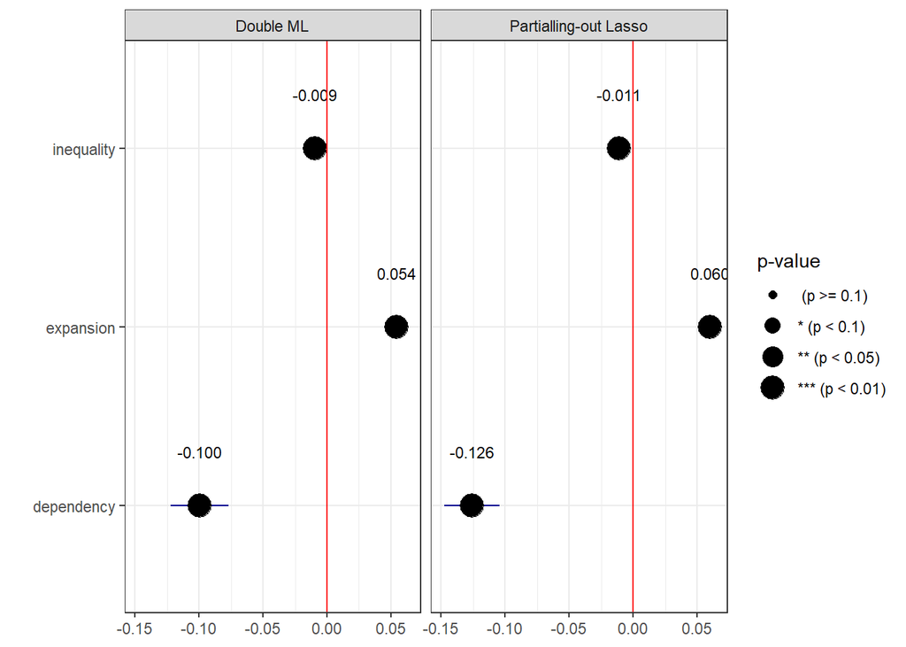

```r
print(Fig_3)
```

The Figure 5 is generated by this code:

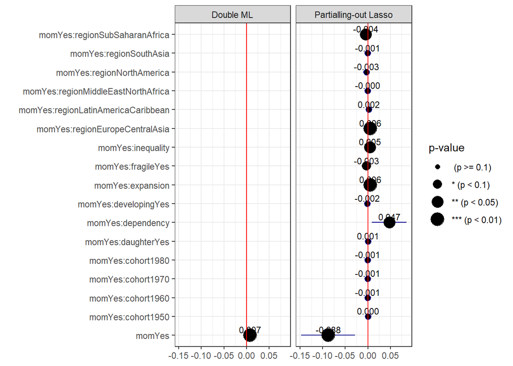

```r
Fig_5 = plot_results(Q2_mom)
print(Fig_5)
```

The Figure 6 is generated by this code:

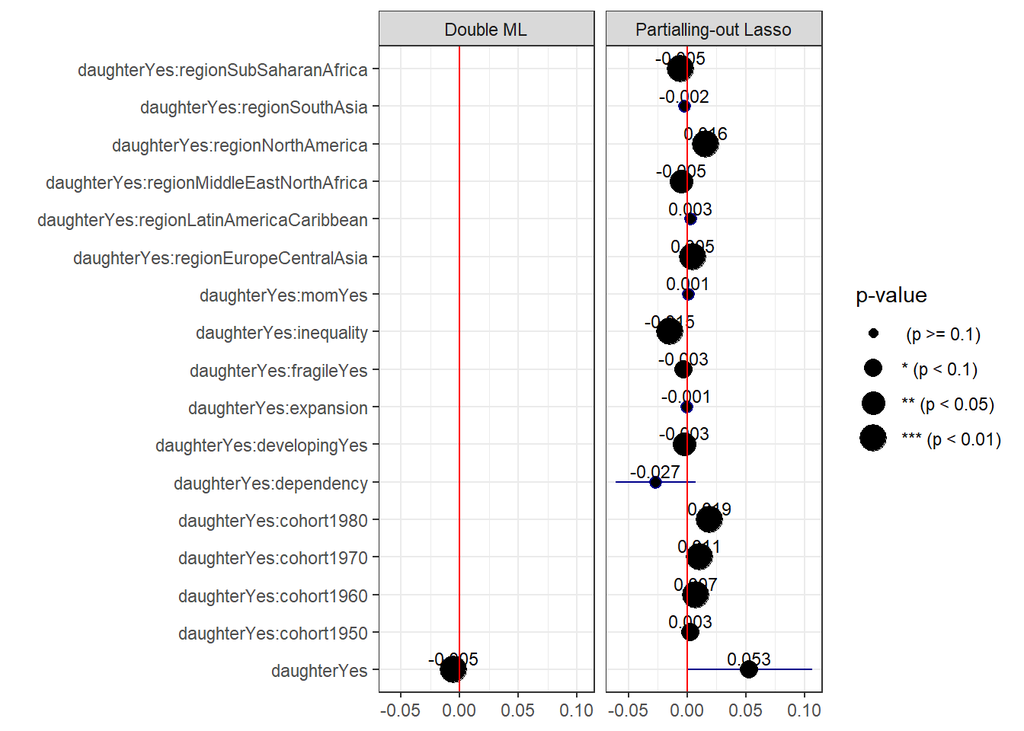

```r
Fig_6 = plot_results(Q2_dau)
print(Fig_6)
```